# Exploratory Data Analysis on Dota 2 matches

## Introduction

#### What is Dota 2

Dota 2 is a popular online multiplayer team strategy game released in 2013 by Valve. Each match consists of ten players, randomly assigned into Dire or Radiant team with five players on each team. The objective is to work together as a team to destroy the opposing side’s base while defending their own. In each match, players will play as one of the many heroes in the selection pool with unique abilities to help them win the game. Throughout the match, players accumulate ‘kills’ and ‘assists’ when they defeat an enemy player or help a team member defeat an enemy player. They will also accumulate ‘deaths’ when they are defeated by players on the enemy team. When players get kills or assists, they are granted some amount of gold and which can be used to buy items for their hero and they also gain exp(experience points for their hero) in order to get stronger and be more useful. When players die, they lose some amount of gold and are temporarily timed out and unable to do anything during that window of time.

#### Objective of this analysis

I will analyze the relationship between the combat variables (kills, deaths, etc.) and the outcome of the matches (win/lose). I will use the 7 years worth of game data my friend Jeff left behind in this analysis. Jeff started playing Dota 2 in December 2012, and quit cold turkey in September 2019. Jeff is sober now after his favourite hero got nerfed (the power of the hero got reduced by the game developers).

#### Dataset

All data used in this analysis are collected from the open source platform, [OpenDota](https://www.opendota.com/). The dataset and code used can be found [here](https://github.com/leyaof/Exploratory-Data-Analysis-on-Dota-2-matches). The dataset consists of all the matches that Jeff has ever played between 2012 - 2019. Each row represents information of each match and each column represents different feature of a match.

## Cleaning Dataset

First, I convert the start time into year, day of the week and hour for better reading of the timestamp.

```r
# Load data
data <- read.csv("player_matches.csv")
# Convert start time into year, day of the week and hour
# Create bin for year, week and hour
year = c()
hour  = c()
week = c()
# Timestamp vector
timestamp = data[,5]
# Get year from timestamp, convert to year and append to data
for (value in timestamp) {
  converted_date = (as.POSIXct(value, origin="1970-01-01"))
  year_str = substr(as.Date(converted_date), start = 1, stop = 4)
  year_int = strtoi(year_str, base = 0L)
  year <- append(year, year_int)
  hour_int = (hour(converted_date))
  hour <- append(hour, hour_int)
  week_str = weekdays(as.Date(converted_date))
  week <- append(week, week_str)
}
# Append modified columns into dataset and remove the old column
df <- data.frame(year = year)
df2 <- data.frame(hour=hour)
df3 <- data.frame(week=week)
data <- cbind(data,df, df2, df3)
data <- subset(data, select = -c(start_time,hero_id,id))
# Convert duration to minutes
data$duration <- data$duration/60
```

Next, I add a new column into the dataframe representing the K/D/A ratio

```r
# Calculate kda using existing columns of kills, deaths and assists using the formula (kills + assists) / deathes
kills_col <- data$kills
deaths_col <- c()
# Add 1 to death values of 0 because we cannot divide by 0
for (value in data$deaths) {
  if (value == 0) {
    deaths_col <- append(deaths_col, value +1)
  }
  else
    deaths_col <- append(deaths_col, value)
}
assists_col <- data$assists
kda <- (kills_col+assists_col)/(deaths_col)
# Round every value in this column to 3 decimal places
kda <- round(kda,3)
# add new column kda into dataframe
data <- cbind(data,kda)
# Reorder column for better reading
data <- data[c(1,2,3,10,11,12,4,5,6,13,7,8,9)]
```

Finally, I want to replace the is_Radiant column with a team column representing which team Jeff was on in each match

```r
# Create bin for team entries
team_col = c()
# convert values in vector to string, with 0 representing Dire and 1 representing Radiant
for (value in data$is_radiant) {
  if (value == 0)
    team_col <- append(team_col, "Dire")
  else
    team_col <- append(team_col, "Radiant")
}
df3 <- data.frame(team_col=team_col)
# Drop is_Radiant column and replace by team_col
data <- subset(data, select=-c(is_radiant))
data <- cbind(data,df3)
```

```r
#output total number of matches played
nrow(data)
```

```
[1] 2191
```

This dataset consists of 2191 rows, i.e there are 2191 games played in total.

```r
# Displaying first 6 rows of the dataset
head(data)
```

|  | match_id | radiant_win | duration | year | hour | week | kills | deaths | assists | kda | win | hero_name | team_col |
| --- | --- | --- | --- | --- | --- | --- | --- | --- | --- | --- | --- | --- | --- |
| 1 | 5007904386 | 1 | 28.83333 | 2019 | 19 | Thursday | 2 | 2 | 10 | 6.000 | 1 | Bristleback | Radiant |
| 2 | 5006381868 | 0 | 58.10000 | 2019 | 21 | Thursday | 12 | 5 | 25 | 7.400 | 1 | Bristleback | Dire |
| 3 | 5006307444 | 1 | 38.65000 | 2019 | 19 | Wednesday | 4 | 6 | 12 | 2.667 | 1 | Bristleback | Radiant |
| 4 | 5006201686 | 1 | 32.81667 | 2019 | 16 | Wednesday | 4 | 1 | 23 | 27.000 | 1 | Bristleback | Radiant |
| 5 | 5005903379 | 0 | 46.26667 | 2019 | 12 | Wednesday | 5 | 10 | 27 | 3.200 | 1 | Bristleback | Dire |
| 6 | 5005807424 | 1 | 44.18333 | 2019 | 11 | Wednesday | 5 | 3 | 18 | 7.667 | 1 | Bristleback | Radiant |

The first 6 rows of the dataset are shown above.

**Description of each column :**

**match_id** : a unique numeric identification of a specific match  
**Radiant_win** : did the Radiant team win. 0 represents no, 1 represents yes  
**duration** : the duration of the match in minutes  
**year** : the year of which the match was played  
**hour** : the hour of the day which the match was played  
**week** : day of the week which the matched was played  
**kills** : the number of times Jeff defeated another player from the opposing team  
**deaths** : the number of times Jeff got defeated by another player from the opposing team  
**assists** : the number of times Jeff helped a teammate to eliminate another player from the opposing team  
**kda** : a measure of performance in a match, calculated as the (kills + assists)/deaths ratio  
**win** : did I win the match. 0 represents no, 1 represents yes  
**hero_name** : the name of the hero used in the match  
**team_col** : the team that Jeff was on

## Looking at the activity between 2012 and 2019

In this section I will look at the amount of activity across different time periods and their associated win rate.

#### How many games won and lost

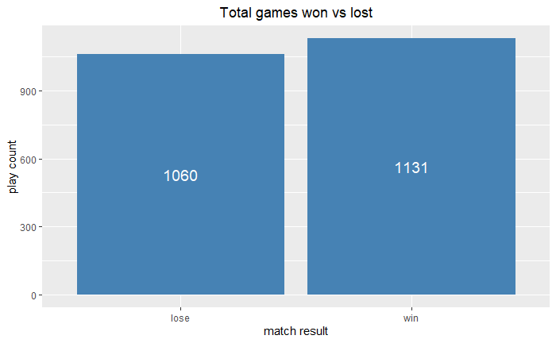

```r
# Vector of win and lose entries
win_lose = data$win
# create bin for win/lose entries
match_result = c()
# Convert values in vector to string, with 0 representing loses and 1 representing wins
for (value in win_lose) {
  if (value == 0)
    match_result <- append(match_result, "lose")
  else
    match_result <- append(match_result, "win")
}
df2 <- data.frame(match_result=match_result)
subdata <- cbind(data,df2)
# Create bar graph comparing the number of matches won and lost
ggplot(subdata, aes(x=match_result)) +
  labs(x = "match result", y="play count")+
  geom_bar(stat="count", fill="steelblue") +
  ggtitle("Total games won vs lost") +
  theme(plot.title = element_text(hjust = 0.5)) +
  geom_text(aes(label=..count..), color="white", position=position_stack(vjust = .5), size=5, stat='count')
```

```r
# Find total and fraction of winning matches
data %>%
  dplyr::summarise(
    total = n(),
    percent_won = mean(win == 1)
    )
```

| total | percent_won |
| --- | --- |
| 2191 | 0.5162026 |

Overall, there are more wins than lost with a win rate of 0.5162 or 51.62%.

#### Lifetime win rate trend

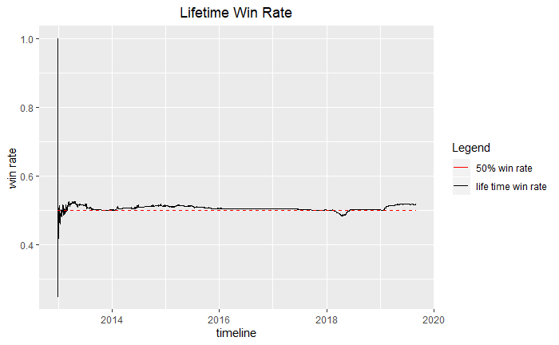

```r
data2 <- read.csv("player_matches.csv")
date = c()
# Timestamp vector
timestamp = data2[,5]
# Get year from timestamp, convert to year and append to data
for (value in timestamp) {
  converted_date = (as.POSIXct(value, origin="1970-01-01"))

  date <- append(date, as.Date(converted_date))
}
data2 <- cbind(data2, date)
data2 <- subset(data2, select= c(date, win))
data2 <- data2[with(data2, order(date)),]
total_games = 1
num_wins = 0
winrate = c()
for (result in data2$win) {
  num_wins = num_wins + result
  current_winrate = num_wins/total_games
  winrate <- append(winrate, current_winrate)
  total_games = total_games + 1
}
data2 <- cbind(data2, winrate)
ggplot(data=data2, aes(x=date, y=winrate, color="life time win rate")) +
  geom_line() +
  geom_line(aes(y=0.5, color="50% win rate"), linetype="dashed", size=0.1) +
  labs(x="timeline", y="win rate", title="Lifetime Win Rate") +
  theme(plot.title = element_text(hjust = 0.5)) +
  scale_colour_manual(name="Legend",
    values=c(`life time win rate`="black", `50% win rate`="red"))
```

The win rate was usually very close to 50% with intervals that were slightly above or below 50%.

#### Activity by hour of the day

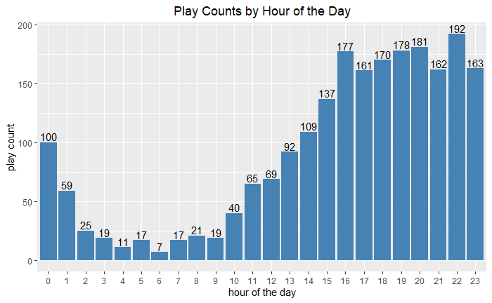

```r
# Create bar graph comparing the number of matches played by the hour of the day
count_hour <- ggplot(subdata, aes(factor(hour))) +
  geom_bar(stat="count", fill="steelblue") +
  geom_text(stat = 'count',aes(label =..count.., vjust = -0.2)) +
  labs(x="hour of the day", y="play count", title="Play Counts by Hour of the Day") +
  theme(plot.title = element_text(hjust = 0.5))
count_hour
```

The vast majority of gameplay happened between 2pm to midnight. This was expected since the period of time between the afternoons up until midnight is usually when most people are awake and active.  
Between 2am to 9am has the lowest play counts, which makes sense since during that period of time usually most people are asleep.

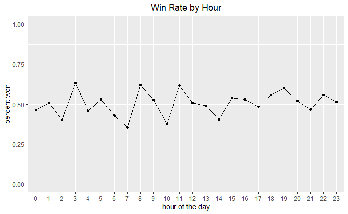

```r
# Summarize winning matches by hour of the day
wl_year <- data %>%
  dplyr::group_by(hour) %>%
  dplyr::summarise(
    total = n(),percent_won = mean(win == 1))
ggplot(wl_year, aes(x=factor(hour), y=percent_won)) +
  geom_point() +
  geom_line(group = 1) +
  ylim(0,1) +
  labs(x="hour of the day", y="percent won", title="Win Rate by Hour") +
  theme(plot.title = element_text(hjust = 0.5))
```

The win rate by the hour seems to fluctuate between 30% and 60%. An interesting note is that both the upper peaks and lower peaks occurs in the morning.

#### Activity by day of the week

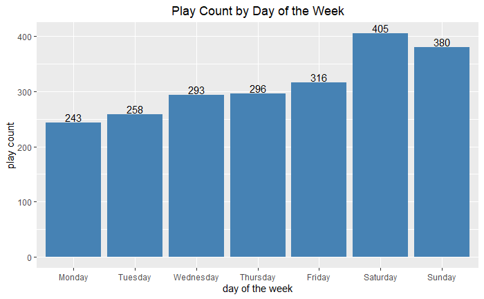

```r
subdata$week <- factor(subdata$week, levels= c("Monday", "Tuesday", "Wednesday", "Thursday", "Friday", "Saturday", "Sunday"))
count_week <- ggplot(subdata, aes(factor(week))) +
  geom_bar(stat="count", fill="steelblue") +
  geom_text(stat = 'count',aes(label =..count.., vjust = -0.2)) +
  labs(x = "day of the week", y="play count", title = "Play Count by Day of the Week") +
  theme(plot.title = element_text(hjust = 0.5))
count_week
```

From the bar graph, we see that there is a steady increase in play counts throughout the weekdays. The weekends had noticeably more games played compared to the weekdays. This can be explained by the fact that there were probably a lot more work assigned on the starting day of the week from school and towards the end of the week there are more free time to spare.

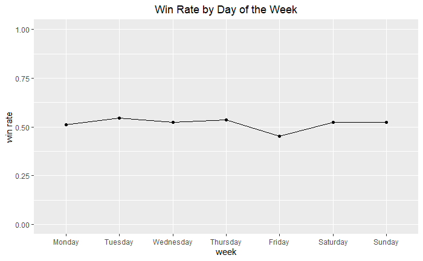

```r
# Summarize winning matches by week
wl_week <- data %>%
  dplyr::group_by(week) %>%
  dplyr::summarise(
    total = n(),percent_won = mean(win == 1))
ggplot(wl_week, aes(x=factor(week, levels= c("Monday", "Tuesday", "Wednesday", "Thursday", "Friday", "Saturday", "Sunday")), y=percent_won)) +
  geom_point() +
  geom_line(group = 1) +
  ylim(0,1) +
  labs(x="week", y="win rate", title="Win Rate by Day of the Week") +
  theme(plot.title = element_text(hjust = 0.5))
```

Overall, there does not seem to be any major difference in win rate throughout the week. Although an interesting note is that Friday is the only day where the win rate is dropped below 50%.

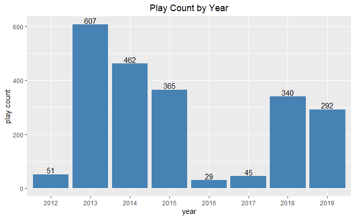

```r
# Create bar graph comparing the number of matches played from 2012 to 2019
count_year <- ggplot(subdata, aes(factor(year))) +
  geom_bar(stat="count", fill="steelblue") +
  geom_text(stat = 'count',aes(label =..count.., vjust = -0.2)) +
  labs(x = "year", y="play count", title="Play Count by Year") +
  theme(plot.title = element_text(hjust = 0.5))

# create column consisting of the match results
result_col <- factor(subdata$match_result)
count_year
```

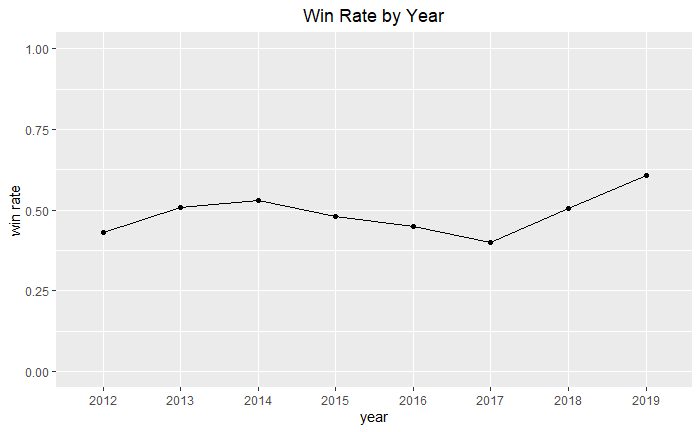

```r
# Summarize winning matches by year
wl_year <- data %>%
  dplyr::group_by(year) %>%
  dplyr::summarise(
    total = n(),percent_won = mean(win == 1))
ggplot(wl_year, aes(x=factor(year), y=percent_won)) +
  geom_point() +
  geom_line(group = 1) +
  ylim(0,1) +
  labs(x="year", y="win rate", title="Win Rate by Year") +
  theme(plot.title = element_text(hjust = 0.5))
```

The years 2012, 2016 and 2017 has considerably lower win rate on the graph compare to other years. This might be the result of lack of data or simply decline in game mechanics for not playing frequently. The linear increase in win rate between 2017-2019 will be discussed later on.

In general, there seems to be an improvement in win rate throughout the years, with the highest win rate being in the year of 2019. For further investigation, I will look at the win rate difference between when Jeff first started playing compared to the most recent matches in terms of hours and days of the week. Since the matches of 2012 happened during the last few days of the year, there are very few number of games played during the year of 2012, so I decided to compare the data between 2013 and 2019.

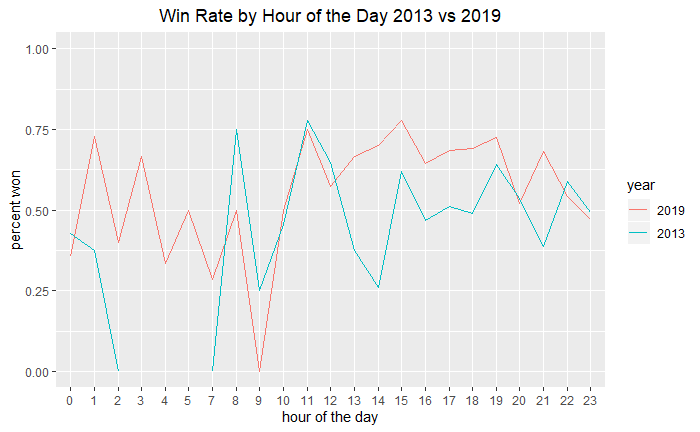

```r
# Create filtered version of only data from the year of 2013
wl_2013 <- data %>%
  dplyr::filter(year == 2013) %>%
  dplyr::group_by(hour) %>%
  dplyr::summarize(total=n(), percent_won=mean(win==1))
# filtering hours without any matches
wl_2013_2 = wl_2013 %>%
  filter(hour <= 2)
wl_2013_7 = wl_2013 %>%
  filter(hour >= 7)
# Create filtered version of only data from the year of 2019
wl_2019 <- data %>%
  dplyr::filter(year == 2019) %>%
  dplyr::group_by(hour) %>%
  dplyr::summarize(total=n(), percent_won=mean(win==1))
# Create line graph comparing the win rate by hour of the day of the year 2013 and 2019
ggplot() +
  geom_line(data=wl_2019, group = 1, aes(x=factor(hour), y=percent_won, color = "#3282b8")) +
  geom_line(data=wl_2013_2, group = 1, aes(x=factor(hour), y=percent_won, color = "#e32249")) +
  geom_line(data=wl_2013_7, group = 1, aes(x=factor(hour), y=percent_won, color = "#e32249")) +
  ylim(0,1) +
  labs(x="hour of the day", y="percent won", title="Win Rate by Hour of the Day 2013 vs 2019") +
  theme(plot.title = element_text(hjust = 0.5)) +
  theme(legend.position="right")+
  scale_color_discrete(name = "year", labels = c("2019", "2013"))
```

Comparing the years of 2013 and 2019 with the win rate by hour of the day, for the most part there is an obvious improvement in the year or 2019 for example in the time frame between 0 to 7 and also between 12 to 22. On the other hand there seem to be a decline in win rate during the time interval of 8 to 10 and 22 to 0. There is a gap between 2am-7am for the year of 2013 because of the lack of data during those hours.

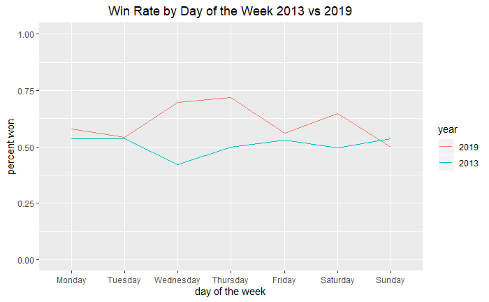

```r
# Create filtered version of only data from the year of 2013
wl_2013 <- data %>%
  dplyr::filter(year == 2013) %>%
  dplyr::group_by(week) %>%
  dplyr::summarize(total=n(), percent_won=mean(win==1))
# Create filtered version of only data from the year of 2019
wl_2019 <- data %>%
  dplyr::filter(year == 2019) %>%
  dplyr::group_by(week) %>%
  dplyr::summarize(total=n(), percent_won=mean(win==1))
wl_2013$week <- factor(wl_2013$week, levels= c("Monday", "Tuesday", "Wednesday", "Thursday", "Friday", "Saturday", "Sunday"))
wl_2019$week <- factor(wl_2019$week, levels= c("Monday", "Tuesday", "Wednesday", "Thursday", "Friday", "Saturday", "Sunday"))
# Create line graph comparing the win rate by day of the week of the year 2013 and 2019
ggplot() +
  geom_line(data=wl_2019, group = 1, aes(x=factor(week), y=percent_won, color = "#3282b8")) +
  geom_line(data=wl_2013, group = 1, aes(x=factor(week), y=percent_won, color = "#e32249")) +
  ylim(0,1) +
  labs(x="day of the week", y="percent won", title="Win Rate by Day of the Week 2013 vs 2019") +
  theme(plot.title = element_text(hjust = 0.5)) +
  theme(legend.position="right") +
  scale_color_discrete(name = "year", labels = c("2019", "2013"))
```

Similar to the results from comparing win rates by hour of the day, the win rate by day of the week for the year of 2019 is a lot better than that of 2013 for the most part with the exception of Sunday where there is a slight decline in win rate for 2019 compared to 2013. The win rate on Tuesdays seem to have stayed about the same with only a faint increase.

## How often are each hero played and how well did each perform?

Previously, we looked at the distribution of play counts across different time variables along with their win rates, in this section I will explore which heroes Jeff dedicated most of his time to.

```r
# Calculate number of times each hero are played in percentage
hero_freq_data =count_(data, vars="hero_name")
```

[output not shown]

```r
occurances = hero_freq_data[,2]
total_occur = sum(occurances)
occurances <- (occurances/total_occur)*100
# Round to 3 decimal places
occurances <- round(occurances, 3)
performance_by_hero <- data %>%
  dplyr::group_by(hero_name) %>%
  # Calculate percentage won by each hero rounded to 3 decimal places
  dplyr::summarize(total=n(), percent_won=round(mean(win==1), 3))
performance_by_hero <- cbind(performance_by_hero,occurances)
# Create subdata consisting of only the variables needed to calculate kda ratio and hero_name
kda_subdata <- subset(data, select = c(kills, deaths, assists, hero_name))
kda_subdata <- kda_subdata %>%
  dplyr::group_by(hero_name) %>%
  # Calculate the sum of kills, deaths and assists of each hero
  dplyr::summarize(kills=sum(kills), deaths=sum(deaths),assists=sum(assists))
# Calculate total kda of each hero
total_kills <- kda_subdata$kills
total_deaths <- kda_subdata$deaths
total_assists <- kda_subdata$assists
total_kda <- (total_kills + total_assists)/total_deaths
# Round to 3 decimal places
total_kda <- round(total_kda, 3)
performance_by_hero <- cbind(performance_by_hero,total_kda)
# Editing column names for better reading
colnames(performance_by_hero)[3] <- "winrate"
colnames(performance_by_hero)[2] <- "number of times played"
colnames(performance_by_hero)[4] <- "times played in percentage"
performance_by_hero <- performance_by_hero[order(performance_by_hero$`number of times played`, decreasing = TRUE),]
performance_by_hero
```

|  | hero_name | number of times played | winrate | times played in percentage | total_kda |
| --- | --- | --- | --- | --- | --- |
| 32 | Gyrocopter | 236 | 0.801 | 10.771 | 6.336 |
| 105 | Windranger | 146 | 0.493 | 6.664 | 2.589 |
| 82 | Sniper | 96 | 0.500 | 4.382 | 3.494 |
| 78 | Silencer | 70 | 0.543 | 3.195 | 2.161 |
| 47 | Luna | 63 | 0.524 | 2.875 | 2.430 |
| 50 | Medusa | 59 | 0.492 | 2.693 | 3.449 |
| 39 | Kunkka | 58 | 0.534 | 2.647 | 2.468 |
| 37 | Juggernaut | 56 | 0.482 | 2.556 | 3.322 |
| 89 | Tidehunter | 50 | 0.620 | 2.282 | 2.875 |
| 44 | Lina | 49 | 0.612 | 2.236 | 2.966 |

[output cut: 99 more lines]

Above is a list of all the heroes ever played, the number of times played, the value expressed as a percentage, their win rate and total kda ratio of each hero. For a better visualization, below are bar graph representations of the above data.

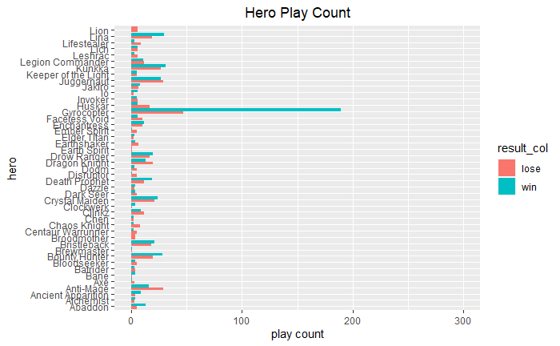

```r
# Get the hero names of the top 45 most played heroes in the match history
hero_names = hero_freq_data$hero_name[1:45]
# Match data of only the top 30 played heroes
top_45_data <-  subdata[subdata$hero_name %in% hero_names,]
# Create column consisting of the match results
result_col <- factor(top_45_data$match_result)
ggplot(top_45_data, aes(factor(hero_name), fill=result_col)) +
  geom_bar(position=position_dodge()) +
  labs(x = "hero", y="play count", color="match result", title = "Hero Play Count") +
  theme(plot.title = element_text(hjust = 0.5)) +
  coord_flip(ylim = c(0,300))
```

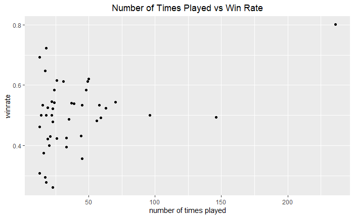

```r
subdata_performance <- head(performance_by_hero, 45)
ggplot(data = subdata_performance, aes(x=`number of times played`, y=winrate)) +
  geom_point() +
  labs(title = "Number of Times Played vs Win Rate") +
  theme(plot.title = element_text(hjust = 0.5))
```

Here on the graph, each dot represents one of the top 45 heroes played with the x-axis correponding to the number of times that hero is played and the y-axis representing the overall win rate for the hero. There is a noticeable cluster grouped around a play count of 30 and win rate of 50, the form does not appear to be linear nor does it have a obvious Direction. It seems that the 80% win rate on Gyrocopter is an outlier!

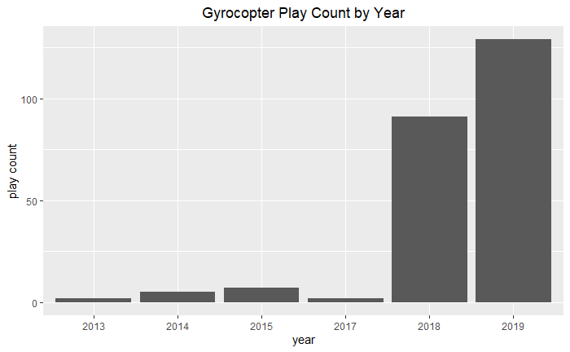

```r
# Create subdata only containing matches played with Gyrocopter
Gyrocopter <- data %>%
  dplyr::filter(hero_name=="Gyrocopter") %>%
  dplyr::group_by(year)
ggplot(data=Gyrocopter, aes(x=factor(year))) +
  geom_bar(stat="count") +
  labs(x = "year", y= "play count", title = "Gyrocopter Play Count by Year") +
  theme(plot.title = element_text(hjust = 0.5))
```

```r
NA
```

There is a drastic increase in the play count with Gyrocopter in the years of 2018 and 2019. This trend and the 80% win rate discovered explains why there was a linear increase in win rate from the line graph describing win rate by year earlier.

## Exploring variables contributing to win rates

#### Visualizing the Correlation matrix

```r
# Creating a sub-dataset for correlation matrix
match_var_data <- subset(data, select = -c(team_col,radiant_win, match_id, hero_name, year, week, hour))
data.cor = cor(match_var_data)
data.cor
```

```
            duration      kills     deaths   assists        kda         win
duration  1.00000000  0.1974150  0.5085815 0.4820959 -0.2137307 -0.04121144
kills     0.19741500  1.0000000 -0.1644657 0.3773872  0.5219858  0.36940912
deaths    0.50858149 -0.1644657  1.0000000 0.1685448 -0.5837528 -0.42342864
assists   0.48209589  0.3773872  0.1685448 1.0000000  0.2357658  0.37021834
kda      -0.21373070  0.5219858 -0.5837528 0.2357658  1.0000000  0.45472166
win      -0.04121144  0.3694091 -0.4234286 0.3702183  0.4547217  1.00000000
```

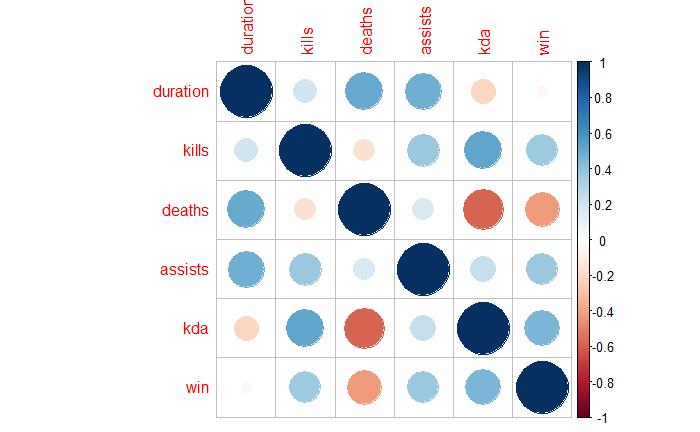

```r
cor_plot <- corrplot(data.cor)
```

```r
col <- colorRampPalette(c("blue", "white", "red"))(20)
```

The more blue a circle is, the more two variables are positively correlated. Similarly, the more red a circle is, the more two variables are negatively correlated.

**Positive correlations :**  
duration : assists, kills, deaths  
assists : duration, kills, deaths, kda, win  
kills : duration, assists, kda, win  
deaths : duration, assists  
kda : assists, kills, win  
win : assists, kills, kda

**Negative correlations :**  
duration : kda, win  
kills : deaths  
deahts : kills, kda, win  
kda : duration, deaths  
win : duration, deaths

#### Exploring the relationship of player K/D/A (kills/deaths/assists) and game durataion on the chance of winning

From the correlation matrix previously we see that the duration is positively correlated with the kills/deaths/assists variable individually, but has a negative relation with the kda ratio along with the chance of winning. On the other hand, the chance of winning has a positive correlation with the kills/assists variables and the kda ratio itself, but has a negative correlation with the number of deaths. Here I will use boxplots to look at these relations further.

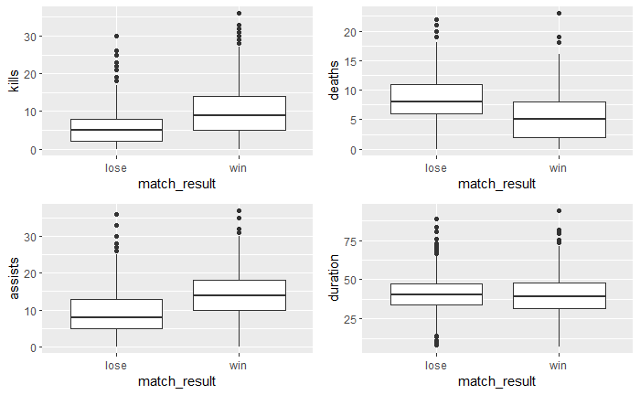

```r
# Create bin for win/lose entries
match_result = c()
# Convert values in vector to string, with 0 representing loses and 1 representing wins
for (value in win_lose) {
  if (value == 0)
    match_result <- append(match_result, "lose")
  else
    match_result <- append(match_result, "win")
}
df2 <- data.frame(match_result=match_result)
subdata <- cbind(data,df2)
match_var_data <- subset(subdata, select = -c(match_id,hero_name, year))
# Create boxplots comparing match result against the kills, deahts, assists and duration variables
kills_impact <- ggplot(match_var_data, aes(x=match_result, y=kills)) +
  geom_boxplot()
deaths_impact <- ggplot(match_var_data, aes(x=match_result, y=deaths)) +
  geom_boxplot()
assists_impact <- ggplot(match_var_data, aes(x=match_result, y=assists)) +
  geom_boxplot()
duration_impact <- ggplot(match_var_data, aes(x=match_result, y=duration)) +
  geom_boxplot()
ggarrange(kills_impact, deaths_impact, assists_impact, duration_impact, ncol = 2 , nrow = 2)
```

The boxplots above compare the spread of the variables kills, deaths, assists and duration separated by the match result of either a win or a lost.

There a positive relationship between the chance of winning and the number of kills and assists. In general, I have more kills and assists when winning than losing. Based on the information so far, this suggests that the value of kills and assists could be potential estimators of whether a match will result in a win.

In addition, there is a negative relationship between the chance of winning and the number of deaths. In general, I usually have more deaths when losing than winning, with some exceptions when this is not the case, as shown in the outlier of the graph.

There does not seem to be a clear difference in game duration for winning and losing matches. However, notice that there are a significant amount of outliers beyond the lower whiskers of a losing match. Potential explanations for this might be teammates disconnecting or quitting during early stages of the match which may result in a great disadvantage for the team.

I want to compare the median of the two groups to better assess these findings. Since the data for kills, deaths and assists is not normally distributed, I will use the Mood’s median test. The null hypothesis is that there is no difference in kills, deaths and assists between winning and losing games.

#### Median test against kills

```r
median_test(match_var_data, kills, match_result)
```

```
$`table`
      above
group  above below
  lose   295   689
  win    659   402

$test
```

| what | value |
| --- | --- |
| statistic | 2.117843e+02 |
| df | 1.000000e+00 |
| P-value | 5.605159e-48 |

```
NA
```

The p-value is 5.605159e-48 which is a lot smaller than the Alpha 0.05, so we reject the null hypothesis and conclude that there is indeed a difference of number of kills comparing the two groups.

#### Median test against deaths

```r
median_test(match_var_data, deaths, match_result)
```

```
$`table`
      above
group  above below
  lose   664   285
  win    302   742

$test
```

| what | value |
| --- | --- |
| statistic | 3.352480e+02 |
| df | 1.000000e+00 |
| P-value | 6.914952e-75 |

```
NA
```

The P-value is 6.914952e-75, similar to above it is extremely small compared to the Alpha of 0.05, so we reject the null hypothesis and conclude that there is a difference of number of deaths comparing the two groups.

#### Median test against assists

```r
median_test(match_var_data, assists, match_result)
```

```
$`table`
      above
group  above below
  lose   340   673
  win    732   325

$test
```

| what | value |
| --- | --- |
| statistic | 2.638739e+02 |
| df | 1.000000e+00 |
| P-value | 2.455356e-59 |

```
NA
```

The p-value is 2.455356e-59, again, this is really small compared to the Alpha of 0.05 and so we are able to reject the null hypothesis and conclude that there is a difference in the number of assists comparing the two groups.

For the game duration variable, we can see from the plot below that is follows a straight line, so in this case the normality holds. Since the distribution is approximately normal, it is appropriate to use a pooled t-test. The null hypothesis here is that there is no difference in game duration between games won or lost.

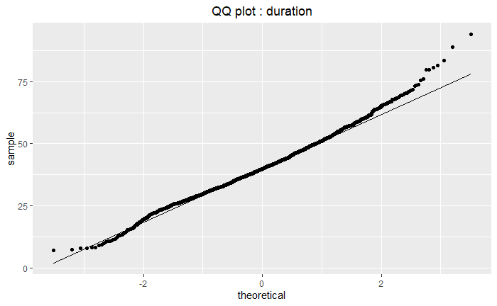

```r
ggplot(match_var_data, aes(sample=duration)) +
  stat_qq() +
  stat_qq_line() +
  labs(title="QQ plot : duration") +
  theme(plot.title = element_text(hjust = 0.5))
```

#### T test against duration

```r
t.test(duration~match_result, match_var_data, var.equal=T)
```

```
    Two Sample t-test

data:  duration by match_result
t = 1.9298, df = 2189, p-value = 0.05376
alternative hypothesis: true difference in means is not equal to 0
95 percent confidence interval:
 -0.01489275  1.85367260
sample estimates:
mean in group lose  mean in group win
          40.98000           40.06061
```

The p-value is 0.05376 which is bigger than the Alpha 0.05, so we fail to reject the null hypothesis. So, there is no evidence that there is a difference in game duration between the two groups.

## Exploring the relationship of being on the Radiant team and the chance of winning

I want to look at any possible difference between the matches being on the Radiant team vs being on the Dire team.

```r
wl_team <- data %>%
  dplyr::group_by(team_col) %>%
  dplyr::summarize(total=n(), percent_won=mean(win==1))
wl_team
```

| team_col | total | percent_won |
| --- | --- | --- |
| Dire | 1115 | 0.4950673 |
| Radiant | 1076 | 0.5381041 |

From the table above it shows that being on the Radiant team does have a slight increase in win rate than being on the Dire team by 4.31%

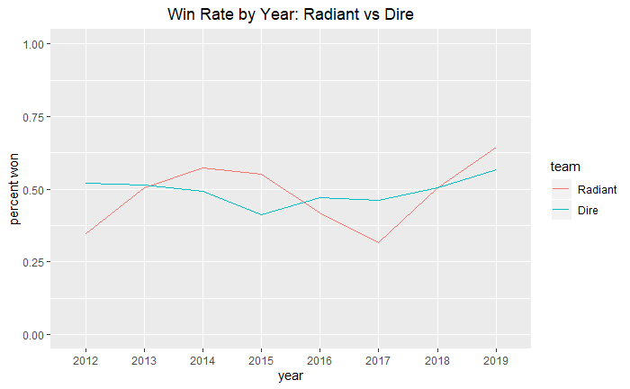

```r
# Create filtered version of only data from the year of 2013
wl_Radiant <- data %>%
  dplyr::filter(team_col == "Radiant") %>%
  dplyr::group_by(year) %>%
  dplyr::summarize(total=n(), percent_won=mean(win==1))
# Create filtered version of only data from the year of 2019
wl_Dire <- data %>%
  dplyr::filter(team_col == "Dire") %>%
  dplyr::group_by(year) %>%
  dplyr::summarize(total=n(), percent_won=mean(win==1))
# Create line graph comparing the win rate by year for Radiant vs Dire
team_wl <- ggplot() +
  geom_line(data=wl_Radiant, group = 1, aes(x=factor(year), y=percent_won, color = "#3282b8")) +
  geom_line(data=wl_Dire, group = 1, aes(x=factor(year), y=percent_won, color = "#e32249")) +
  ylim(0,1) +
  labs(x="year", y="percent won", title="Win Rate by Year: Radiant vs Dire") +
  theme(plot.title = element_text(hjust = 0.5)) +
  theme(legend.position="right") +
  scale_color_discrete(name = "team", labels = c("Radiant", "Dire"))
team_wl
```

On the years 2012, 2016 and 2017 the Dire team had a higher win rate than Radiant, but recall previously that there was a significantly low play count for all those years. On years where there are a lot more play counts (2013-2015, 2018-219), the Radiant team had a higher win rate than Dire. Because of the significant amount of data in those years, it is more reliable to believe that the Radiant team has a higher win rate than Dire overall. This is evidenced by the previous table which showed a 4.31% higher win rate for the Radiant team.

Let’s check if there are any relationships between the variables kills, deaths and assists against the two team.

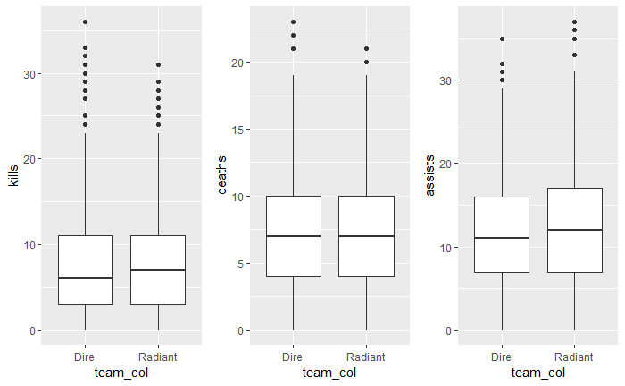

```r
match_team_data <- subset(data, select = -c(match_id,hero_name, year))
# Create boxplots comparing Radiant and Dire team against the kills, deahts and assists variables
kills_impact <- ggplot(match_team_data, aes(x=team_col, y=kills)) +
  geom_boxplot()
deaths_impact <- ggplot(match_team_data, aes(x=team_col, y=deaths)) +
  geom_boxplot()
assists_impact <- ggplot(match_team_data, aes(x=team_col, y=assists)) +
  geom_boxplot()
ggarrange(kills_impact, deaths_impact, assists_impact,  ncol = 3 , nrow = 1)
```

The box plots show a slight Radiant team advantage in the median numbers of kills and assists. However, there was almost no team difference in median numbers of deaths. To assess this further, I want to compare the medians of these two groups (radian and Dire). But first we need to check the data for normality.

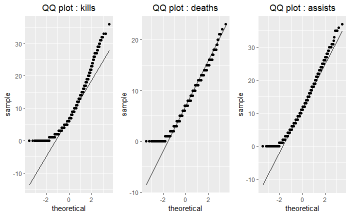

```r
qq_kills <- ggplot(match_team_data, aes(sample=kills)) +
  stat_qq() +
  stat_qq_line() +
  labs(title = "QQ plot : kills") +
  theme(plot.title = element_text(hjust = 0.5))
qq_deaths <- ggplot(match_team_data, aes(sample=deaths)) +
  stat_qq() +
  stat_qq_line() +
  labs(title = "QQ plot : deaths") +
  theme(plot.title = element_text(hjust = 0.5))
qq_assists <- ggplot(match_team_data, aes(sample=assists)) +
  stat_qq() +
  stat_qq_line() +
  labs(title = "QQ plot : assists") +
  theme(plot.title = element_text(hjust = 0.5))
ggarrange(qq_kills, qq_deaths, qq_assists,  ncol = 3 , nrow = 1)
```

Since all three QQ plots have obvious curves, it implies that the data does not agree with the normality assumption. Therefore, the Mood’s median test would be a better fit for this case. The null hypothesis is that there is no difference between the two groups.

#### Median test against kills

```r
median_test(match_team_data, kills, team_col)
```

```
$`table`
         above
group     above below
  Dire      477   566
  Radiant   477   525

$test
```

| what | value |
| --- | --- |
| statistic | 0.7190724 |
| df | 1.0000000 |
| P-value | 0.3964483 |

```
NA
```

The p-value is 0.3964483 and is bigger than Alpha of 0.05, which fails to reject the null hypothesis so therefore the median difference is zero and there is no evidence that the number of kills are any different amongst either teams on average.

#### Median test against deaths

```r
median_test(match_team_data, deaths, team_col)
```

```
$`table`
         above
group     above below
  Dire      505   514
  Radiant   461   513

$test
```

| what | value |
| --- | --- |
| statistic | 0.9895628 |
| df | 1.0000000 |
| P-value | 0.3198493 |

```
NA
```

The p-value is 0.3198493. Similar to above, we fail to reject the null hypothesis that there is no difference in deaths between either teams.

#### Median test against assists

```r
median_test(match_team_data, assists, team_col)
```

```
$`table`
         above
group     above below
  Dire      527   524
  Radiant   545   474

$test
```

| what | value |
| --- | --- |
| statistic | 2.3131156 |
| df | 1.0000000 |
| P-value | 0.1282867 |

```
NA
```

The p-value is 0.1282867, again, we are unable to reject the null hypothesis that there is no difference in assists between either teams.

Based on the above evidence, I conclude that there is no difference between the groups Radiant and Dire in terms of kills, deaths or assists. However, we previously discovered that the win rate of being on the Radiant team is 4.31% than being on the Dire team. Therefore, there may be other unaccounted factors contributed to the win rate that was not recorded in the dataset used in this project.

## Findings

- There is no clear advantage to being on either team in terms of kills, deaths or assists.
- The number of kills and assists generally has a positive relation with the chance of winning the game, while the number of deaths has a negative relation.
- The duration of the game has little impact on the chance of winning
- The lifetime win rate fluctuates around 50%